# **Assignment 01 - Group 3**

Daniel + Megan + Mike

26 October 2021

# **research question**

How well does a census tract’s percentage of single-family homes and location relative to metropolitan center predict the average home value and tenure period in homes for the Commonwealth of Massachusetts?

# **prior research**

While the correlation between diversity of housing types and racial and economic diversity in neighborhoods have previously been established, this study investigated a potential relationship between housing typology and foreclosures. In fact, they found a positive (but varied) correlation between type and stability—neighborhoods with a range of housing stock had lower foreclosure and sales rates (Chakraborty et al 2018). Additionally, hedonic modelling of home values have been shown to respond to distance to city center. Longer distance from the metropolitan center correlates with lower property values in the magnitude of 1.82%. However, this relationship is highly income dependent, where devaluation associated with distance is higher for low-income individuals than for high-income individuals (Kestens et al. 2006).

- Chakraborty, Arnab and McMillan, Andrew, “Is Housing Diversity Good for Community Stability?: Evidence from the Housing Crisis,” *Journal of Planning Education and Research*, (2018), https://journals.sagepub.com/doi/10.1177/0739456X18810787
- Kestens, Yan, Theriault, Marius, and Des Rosiers Francois “Heterogeneity in hedonic modelling of house prices: looking at buyers’ household profiles,” *Journal of Geographical Systems*, (2006), https://link.springer.com/article/10.1007/s10109-005-0011-8

# **data**

The sample population for this study is the full set of all census tracts in the Commonwealth of Massachusetts.

The analysis will include the following variables:

CONTINUOUS

- Percentage of Single, Detached Housing Units (United States Census Bureau 2019)
- Geographic Mobility (percent of People Who Moved in During the Past Year) (United States Census Bureau 2019)
- Average value of Single, Detached Housing Units (United States Census Bureau 2019)

CATEGORICAL

- Majority White or Not Majority White Population (United States Census Bureau 2020)
- Urban Rural Classification (National Center for Health Statistics 2013)

## **data table**

The dataset includes 1478 census tracks. Note - the housing value is only available for 337 out of your 1478 census tracts, so we have filtered the data to only include those, which substantially reduces the sample size.

| GEOID | pct_sf_home | pct_moved | avg_sf_home_val | maj_white | GEOID_county | type |
| --- | --- | --- | --- | --- | --- | --- |
| 25027732302 | 0.2649573 | 0.2962963 | 140626.9 | TRUE | 25027 | Medium metro |
| 25001010100 | 0.3952991 | 0.0741453 | 366285.4 | TRUE | 25001 | Small metro |
| 25001015200 | 0.8540233 | 0.0332037 | 199807.0 | TRUE | 25001 | Small metro |
| 25001014700 | 0.8324324 | 0.1147854 | 185064.2 | TRUE | 25001 | Small metro |
| 25017337101 | 0.6613516 | 0.0842825 | 447660.2 | TRUE | 25017 | Large fringe metro |
| 25023504101 | 0.8820850 | 0.2869433 | 532236.4 | TRUE | 25023 | Large fringe metro |

# **descriptive statistics**

## **continuous variables**

The continuous variables we use are:

- percentage of single, detached housing units
- geographic mobility
- average value of single, detached housing units

[output not shown]

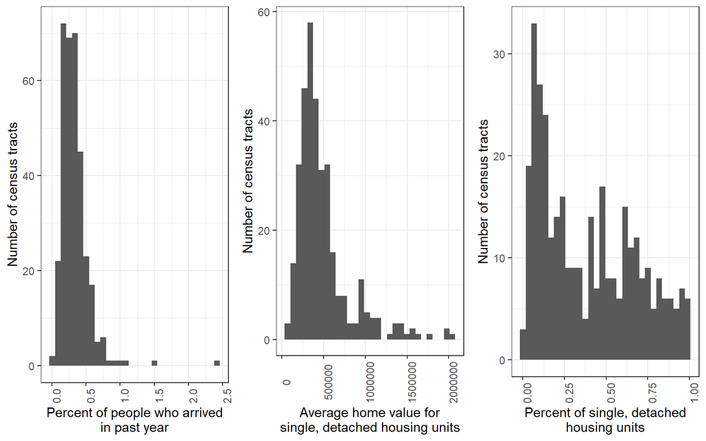

## **categorical variables**

The categorical variables we use are:

- Majority White or Non-Majority White Classification of Census Tract
- Urban-Rural Classification

### **census tracts with a majority white population**

Unsurprisingly, the majority of the census tracts in Massachusetts contain a majority white population.

| Racial Composition of Census Tract | Sample Proportion | 95-percent confidence - low | 95-percent confidence - high |
| --- | --- | --- | --- |
| Majority White | 91 | 88 | 94 |
| Majority Non-White | 9 | 6 | 12 |

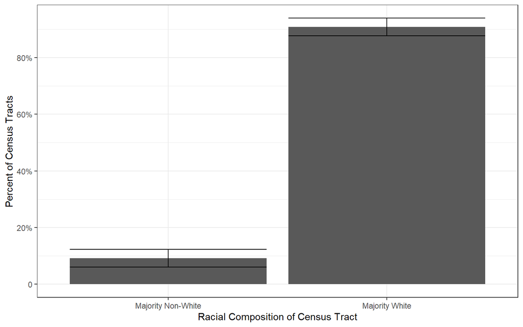

### **urban-rural classifications**

Most census tracts had an urban-rural classification as “large fringe metro.”

| County Type of Census Tract | Sample proportion | 95-percent confidence - low | 95-percent confidence - high |
| --- | --- | --- | --- |
| Large central metro | 19 | 15 | 24 |
| Large fringe metro | 64 | 59 | 69 |
| Medium metro | 12 | 9 | 16 |
| Small metro | 3 | 1 | 5 |
| Micropolitan | 1 | 0 | 2 |
| Non-core | 0 | NaN | NaN |

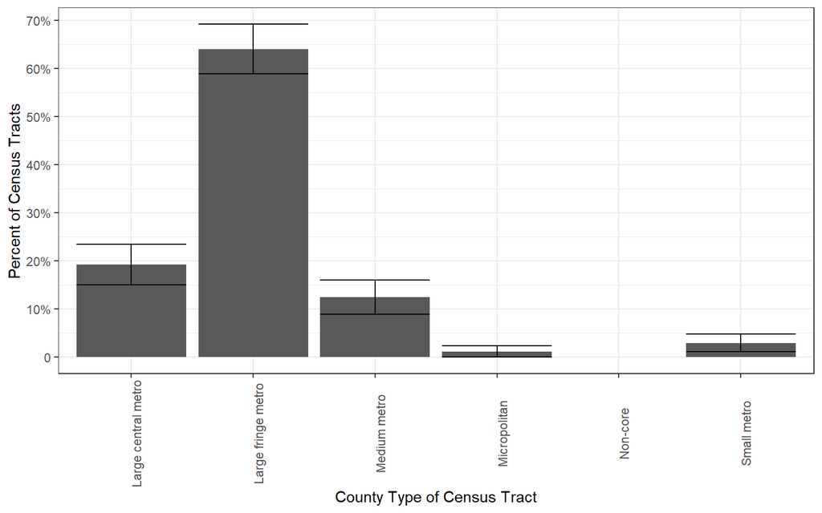

```r
cor.test(~ avg_sf_home_val+ pct_moved, data = data)
```

```
##
##  Pearson's product-moment correlation
##
## data:  avg_sf_home_val and pct_moved
## t = 4.1725, df = 335, p-value = 3.843e-05
## alternative hypothesis: true correlation is not equal to 0
## 95 percent confidence interval:
##  0.1182400 0.3214691
## sample estimates:
##       cor
## 0.2222675
```

```r
cor.test(~ avg_sf_home_val+ pct_sf_home, data = data)
```

```
##
##  Pearson's product-moment correlation
##
## data:  avg_sf_home_val and pct_sf_home
## t = -4.4686, df = 335, p-value = 1.079e-05
## alternative hypothesis: true correlation is not equal to 0
## 95 percent confidence interval:
##  -0.3355110 -0.1337306
## sample estimates:
##        cor
## -0.2371773
```

```r
moved_model <- lm(avg_sf_home_val ~ pct_moved, data = data)

summary(moved_model)
```

```
##
## Call:
## lm(formula = avg_sf_home_val ~ pct_moved, data = data)
##
## Residuals:
##     Min      1Q  Median      3Q     Max
## -889767 -188203  -83728   74450 1529558
##
## Coefficients:
##             Estimate Std. Error t value Pr(>|t|)
## (Intercept)   376393      32413  11.613  < 2e-16 ***
## pct_moved     347767      83347   4.173 3.84e-05 ***
## ---
## Signif. codes:  0 '***' 0.001 '**' 0.01 '*' 0.05 '.' 0.1 ' ' 1
##
## Residual standard error: 321400 on 335 degrees of freedom
## Multiple R-squared:  0.0494, Adjusted R-squared:  0.04657
## F-statistic: 17.41 on 1 and 335 DF,  p-value: 3.843e-05
```

```r
sf_model <- lm(avg_sf_home_val ~ pct_sf_home, data = data)

summary(sf_model)
```

```
##
## Call:
## lm(formula = avg_sf_home_val ~ pct_sf_home, data = data)
##
## Residuals:
##     Min      1Q  Median      3Q     Max
## -499661 -198266  -73658   75135 1485740
##
## Coefficients:
##             Estimate Std. Error t value Pr(>|t|)
## (Intercept)   596337      29469  20.236  < 2e-16 ***
## pct_sf_home  -271823      60830  -4.469 1.08e-05 ***
## ---
## Signif. codes:  0 '***' 0.001 '**' 0.01 '*' 0.05 '.' 0.1 ' ' 1
##
## Residual standard error: 320300 on 335 degrees of freedom
## Multiple R-squared:  0.05625,    Adjusted R-squared:  0.05344
## F-statistic: 19.97 on 1 and 335 DF,  p-value: 1.079e-05
```

```r
t.test(avg_sf_home_val ~ maj_white, data)
```

```
##
##  Welch Two Sample t-test
##
## data:  avg_sf_home_val by maj_white
## t = -6.3171, df = 103.06, p-value = 6.867e-09
## alternative hypothesis: true difference in means between group FALSE and group TRUE is not equal to 0
## 95 percent confidence interval:
##  -232008.8 -121138.1
## sample estimates:
## mean in group FALSE  mean in group TRUE
##            329874.9            506448.4
```

```r
white_model <- lm(avg_sf_home_val ~ maj_white, data = data)

summary(white_model)
```

```
##
## Call:
## lm(formula = avg_sf_home_val ~ maj_white, data = data)
##
## Residuals:
##     Min      1Q  Median      3Q     Max
## -413371 -203854  -83131   59711 1560675
##
## Coefficients:
##               Estimate Std. Error t value Pr(>|t|)
## (Intercept)     329875      58492   5.640 3.63e-08 ***
## maj_whiteTRUE   176574      61384   2.877  0.00428 **
## ---
## Signif. codes:  0 '***' 0.001 '**' 0.01 '*' 0.05 '.' 0.1 ' ' 1
##
## Residual standard error: 325700 on 335 degrees of freedom
## Multiple R-squared:  0.0241, Adjusted R-squared:  0.02119
## F-statistic: 8.275 on 1 and 335 DF,  p-value: 0.004278
```

```r
data <- data %>%
  mutate(type = as.factor(type)) %>%
  mutate(type = relevel(type, "Large central metro"))

type_model <- lm(avg_sf_home_val ~ type, data)

summary(type_model)
```

```
##
## Call:
## lm(formula = avg_sf_home_val ~ type, data = data)
##
## Residuals:
##     Min      1Q  Median      3Q     Max
## -435707 -186514  -71036   65474 1524460
##
## Coefficients:
##                        Estimate Std. Error t value Pr(>|t|)
## (Intercept)              527901      38702  13.640  < 2e-16 ***
## typeLarge fringe metro    14762      44143   0.334   0.7383
## typeMedium metro        -286602      61773  -4.640 5.03e-06 ***
## typeMicropolitan        -307097     160741  -1.911   0.0569 .
## typeSmall metro         -262622     105989  -2.478   0.0137 *
## ---
## Signif. codes:  0 '***' 0.001 '**' 0.01 '*' 0.05 '.' 0.1 ' ' 1
##
## Residual standard error: 312000 on 332 degrees of freedom
## Multiple R-squared:  0.1122, Adjusted R-squared:  0.1015
## F-statistic: 10.49 on 4 and 332 DF,  p-value: 5.164e-08
```